# **Loan Default Prediction**

## **A bank's consumer credit department aims to simplify the decision-making process for home equity lines of credit to be accepted. To do this, they will adopt the Equal Credit Opportunity Act's guidelines to establish an empirically derived and statistically sound model for credit scoring. The model will be based on the data obtained via the existing loan underwriting process from recent applicants who have been given credit. The model will be built from predictive modeling techniques, but the model created must be interpretable enough to provide a justification for any adverse behavior (rejections).**

## **The Context:**

## - Why is this problem important to solve?

## **A major proportion of retail bank profit comes from interests in the form of home loans. These loans are borrowed by regular income/high-earning customers. Banks are most fearful of defaulters, as bad loans (NPA) usually eat up a major chunk of their profits. Therefore, it is important for banks to be judicious while approving loans for their customer base. The approval process for the loans is multifaceted. Through this process, the bank tries to check the creditworthiness of the applicant on the basis of a manual study of various aspects of the application. The entire process is not only effort-intensive but also prone to ong judgment/approval owing to human error and biases. There have been attempts by many banks to automate this process by using heuristics. But with the advent of data science and machine learning, the focus has shifted to building machines that can learn this approval process and make it free of biases and more efficient. At the same time, one important thing to keep in mind is to make sure that the machine does not learn the biases that previously crept in because of the human approval process.**

### **The objective:**

## **- What is the intended goal?**

### **Build a classification model to predict clients who are likely to default on their loan and give recommendations to the bank on the important features to consider while approving a loan.**

### **The key questions:**

## **- What are the key questions that need to be answered?**

**1. Whether the customer is worthy enough to pay back the loan or will be a defaulter** or **Is this applicant likely to repay the loan?**

### **The problem formulation**:

### **- What is it that we are trying to solve using data science?**

**Build a model that checks the creditworthiness of the applicant.**  
**Build a ML classification model that improves risk management and operational efficiency**

## **Data Description:**

The Home Equity dataset (HMEQ) contains baseline and loan performance information for 5,960 recent home equity loans. The target (BAD) is a binary variable that indicates whether an applicant has ultimately defaulted or has been severely delinquent. This adverse outcome occurred in 1,189 cases (20 percent). 12 input variables were registered for each applicant.

- **BAD:** 1 = Client defaulted on loan, 0 = loan repaid
- **LOAN:** Amount of loan approved.
- **MORTDUE:** Amount due on the existing mortgage.
- **VALUE:** Current value of the property.
- **REASON:** Reason for the loan request. (HomeImp = home improvement, DebtCon= debt consolidation which means taking out a new loan to pay off other liabilities and consumer debts)
- **JOB:** The type of job that loan applicant has such as manager, self, etc.
- **YOJ:** Years at present job.
- **DEROG:** Number of major derogatory reports (which indicates a serious delinquency or late payments).
- **DELINQ:** Number of delinquent credit lines (a line of credit becomes delinquent when a borrower does not make the minimum required payments 30 to 60 days past the day on which the payments were due).
- **CLAGE:** Age of the oldest credit line in months.
- **NINQ:** Number of recent credit inquiries.
- **CLNO:** Number of existing credit lines.
- **DEBTINC:** Debt-to-income ratio (all your monthly debt payments divided by your gross monthly income. This number is one way lenders measure your ability to manage the monthly payments to repay the money you plan to borrow.

## **Import the necessary libraries and Data**

```python
import pandas as pd

import numpy as np

import matplotlib.pyplot as plt

import seaborn as sns
import math as math


import shap

import warnings
warnings.filterwarnings('ignore') # To get rid of warning messages

# Remove scientific notations and display numbers with 2 decimal points instead
pd.options.display.float_format = '{:,.2f}'.format

# Update default background style of plots
sns.set_style(style = 'darkgrid')

# To scale the data using z-score
from sklearn.preprocessing import StandardScaler

from sklearn.model_selection import train_test_split

# Algorithms to use

from sklearn.linear_model import LogisticRegression
from sklearn import tree

from sklearn.tree import DecisionTreeClassifier, plot_tree
from sklearn.ensemble import BaggingClassifier
from xgboost import XGBClassifier

from sklearn.ensemble import RandomForestClassifier

# Metrics to evaluate the model
from sklearn import metrics

from sklearn.metrics import classification_report, precision_recall_curve, recall_score, precision_score, accuracy_score, f1_score
from sklearn.metrics import confusion_matrix
# For tuning the model
from sklearn.model_selection import GridSearchCV

# To ignore warnings
import warnings
warnings.filterwarnings("ignore")
```

## **Data Overview**

- Reading the dataset
- Understanding the shape of the dataset
- Checking the data types
- Checking for missing values
- Checking for duplicated values

```python
from google.colab import drive
drive.mount('/content/drive')
```

## Summary Statistics

```python
# Reading the dataset
data = pd.read_csv('/content/drive/MyDrive/hmeq.csv')
```

```python
data.head()
```

|  | BAD | LOAN | MORTDUE | VALUE | REASON | JOB | YOJ | DEROG | DELINQ | CLAGE | NINQ | CLNO | DEBTINC |
| --- | --- | --- | --- | --- | --- | --- | --- | --- | --- | --- | --- | --- | --- |
| 0 | 1 | 1100 | 25,860.00 | 39,025.00 | HomeImp | Other | 10.50 | 0.00 | 0.00 | 94.37 | 1.00 | 9.00 | NaN |
| 1 | 1 | 1300 | 70,053.00 | 68,400.00 | HomeImp | Other | 7.00 | 0.00 | 2.00 | 121.83 | 0.00 | 14.00 | NaN |
| 2 | 1 | 1500 | 13,500.00 | 16,700.00 | HomeImp | Other | 4.00 | 0.00 | 0.00 | 149.47 | 1.00 | 10.00 | NaN |
| 3 | 1 | 1500 | NaN | NaN | NaN | NaN | NaN | NaN | NaN | NaN | NaN | NaN | NaN |
| 4 | 0 | 1700 | 97,800.00 | 112,000.00 | HomeImp | Office | 3.00 | 0.00 | 0.00 | 93.33 | 0.00 | 14.00 | NaN |

```python
#Checking the shape of dataset
data.shape
```

```
(5960, 13)
```

```python
# summary statistics
data.describe().T
```

|  | count | mean | std | min | 25% | 50% | 75% | max |
| --- | --- | --- | --- | --- | --- | --- | --- | --- |
| BAD | 5,960.00 | 0.20 | 0.40 | 0.00 | 0.00 | 0.00 | 0.00 | 1.00 |
| LOAN | 5,960.00 | 18,607.97 | 11,207.48 | 1,100.00 | 11,100.00 | 16,300.00 | 23,300.00 | 89,900.00 |
| MORTDUE | 5,442.00 | 73,760.82 | 44,457.61 | 2,063.00 | 46,276.00 | 65,019.00 | 91,488.00 | 399,550.00 |
| VALUE | 5,848.00 | 101,776.05 | 57,385.78 | 8,000.00 | 66,075.50 | 89,235.50 | 119,824.25 | 855,909.00 |
| YOJ | 5,445.00 | 8.92 | 7.57 | 0.00 | 3.00 | 7.00 | 13.00 | 41.00 |
| DEROG | 5,252.00 | 0.25 | 0.85 | 0.00 | 0.00 | 0.00 | 0.00 | 10.00 |
| DELINQ | 5,380.00 | 0.45 | 1.13 | 0.00 | 0.00 | 0.00 | 0.00 | 15.00 |
| CLAGE | 5,652.00 | 179.77 | 85.81 | 0.00 | 115.12 | 173.47 | 231.56 | 1,168.23 |
| NINQ | 5,450.00 | 1.19 | 1.73 | 0.00 | 0.00 | 1.00 | 2.00 | 17.00 |
| CLNO | 5,738.00 | 21.30 | 10.14 | 0.00 | 15.00 | 20.00 | 26.00 | 71.00 |
| DEBTINC | 4,693.00 | 33.78 | 8.60 | 0.52 | 29.14 | 34.82 | 39.00 | 203.31 |

```python
data.info()
```

```
<class 'pandas.core.frame.DataFrame'>
RangeIndex: 5960 entries, 0 to 5959
Data columns (total 13 columns):
 #   Column   Non-Null Count  Dtype
---  ------   --------------  -----
 0   BAD      5960 non-null   int64
 1   LOAN     5960 non-null   int64
 2   MORTDUE  5442 non-null   float64
 3   VALUE    5848 non-null   float64
 4   REASON   5708 non-null   object
 5   JOB      5681 non-null   object
 6   YOJ      5445 non-null   float64
 7   DEROG    5252 non-null   float64
 8   DELINQ   5380 non-null   float64
 9   CLAGE    5652 non-null   float64
 10  NINQ     5450 non-null   float64
 11  CLNO     5738 non-null   float64
 12  DEBTINC  4693 non-null   float64
dtypes: float64(9), int64(2), object(2)
memory usage: 605.4+ KB
```

```python
# Analyzing missing values
(data.isnull().sum())
```

|  | 0 |
| --- | --- |
| BAD | 0 |
| LOAN | 0 |
| MORTDUE | 518 |
| VALUE | 112 |
| REASON | 252 |
| JOB | 279 |
| YOJ | 515 |
| DEROG | 708 |
| DELINQ | 580 |
| CLAGE | 308 |
| NINQ | 510 |
| CLNO | 222 |
| DEBTINC | 1267 |

**dtype:** int64

Out of 13 columns, 11 have null values, Bad and Loan do not have any null value :

```python
data.isnull().sum() / len(data) * 100
```

|  | 0 |
| --- | --- |
| BAD | 0.00 |
| LOAN | 0.00 |
| MORTDUE | 8.69 |
| VALUE | 1.88 |
| REASON | 4.23 |
| JOB | 4.68 |
| YOJ | 8.64 |
| DEROG | 11.88 |
| DELINQ | 9.73 |
| CLAGE | 5.17 |
| NINQ | 8.56 |
| CLNO | 3.72 |
| DEBTINC | 21.26 |

**dtype:** float64

1. Mortdue, Delinq, Nimq have approximately have about 10 percent of data missing.
2. Debtinc have approximately 21% of missing data
3. Reason, Job, Clage, CLNO) have around 1% - 5% of missing values.
4. Bad, Loan do not have any missing value.

```python
data.duplicated().sum()
```

```
np.int64(0)
```

**There is not dulplicate data**

```python
cols = data.select_dtypes(['object']).columns.tolist()
#adding target variable to this list as this is a classification problem and the target variable is categorical

cols.append('BAD')
```

```python
cols
```

```
['REASON', 'JOB', 'BAD']
```

```python
# Changing the data type of object type column to category.

for i in cols:
    data[i] = data[i].astype("category")
```

```python
# Checking the info again and the datatype of different variable

data.info()
```

```
<class 'pandas.core.frame.DataFrame'>
RangeIndex: 5960 entries, 0 to 5959
Data columns (total 13 columns):
 #   Column   Non-Null Count  Dtype
---  ------   --------------  -----
 0   BAD      5960 non-null   category
 1   LOAN     5960 non-null   int64
 2   MORTDUE  5442 non-null   float64
 3   VALUE    5848 non-null   float64
 4   REASON   5708 non-null   category
 5   JOB      5681 non-null   category
 6   YOJ      5445 non-null   float64
 7   DEROG    5252 non-null   float64
 8   DELINQ   5380 non-null   float64
 9   CLAGE    5652 non-null   float64
 10  NINQ     5450 non-null   float64
 11  CLNO     5738 non-null   float64
 12  DEBTINC  4693 non-null   float64
dtypes: category(3), float64(9), int64(1)
memory usage: 483.7 KB
```

- Observations from Summary Statistics

```python
bad_loans_equal_to_1 = data[data['BAD'] == 1]
```

```python
bad_loans_equal_to_1.describe().T
```

|  | count | mean | std | min | 25% | 50% | 75% | max |
| --- | --- | --- | --- | --- | --- | --- | --- | --- |
| LOAN | 1,189.00 | 16,922.12 | 11,418.46 | 1,100.00 | 9,200.00 | 14,900.00 | 21,700.00 | 77,400.00 |
| MORTDUE | 1,083.00 | 69,460.45 | 47,588.19 | 2,063.00 | 39,946.50 | 60,279.00 | 85,864.50 | 399,550.00 |
| VALUE | 1,084.00 | 98,172.85 | 74,339.82 | 8,800.00 | 59,368.25 | 82,000.00 | 116,000.00 | 855,909.00 |
| YOJ | 1,124.00 | 8.03 | 7.10 | 0.00 | 2.00 | 6.00 | 12.00 | 41.00 |
| DEROG | 1,102.00 | 0.71 | 1.47 | 0.00 | 0.00 | 0.00 | 1.00 | 10.00 |
| DELINQ | 1,117.00 | 1.23 | 1.90 | 0.00 | 0.00 | 0.00 | 2.00 | 15.00 |
| CLAGE | 1,111.00 | 150.19 | 84.95 | 0.00 | 96.03 | 132.87 | 193.28 | 1,168.23 |
| NINQ | 1,114.00 | 1.78 | 2.25 | 0.00 | 0.00 | 1.00 | 3.00 | 17.00 |
| CLNO | 1,136.00 | 21.21 | 11.81 | 0.00 | 13.00 | 20.00 | 28.00 | 71.00 |
| DEBTINC | 403.00 | 39.39 | 17.72 | 0.52 | 32.38 | 38.08 | 43.29 | 203.31 |

```python
data.describe().T
```

|  | count | mean | std | min | 25% | 50% | 75% | max |
| --- | --- | --- | --- | --- | --- | --- | --- | --- |
| LOAN | 5,960.00 | 18,607.97 | 11,207.48 | 1,100.00 | 11,100.00 | 16,300.00 | 23,300.00 | 89,900.00 |
| MORTDUE | 5,442.00 | 73,760.82 | 44,457.61 | 2,063.00 | 46,276.00 | 65,019.00 | 91,488.00 | 399,550.00 |
| VALUE | 5,848.00 | 101,776.05 | 57,385.78 | 8,000.00 | 66,075.50 | 89,235.50 | 119,824.25 | 855,909.00 |
| YOJ | 5,445.00 | 8.92 | 7.57 | 0.00 | 3.00 | 7.00 | 13.00 | 41.00 |
| DEROG | 5,252.00 | 0.25 | 0.85 | 0.00 | 0.00 | 0.00 | 0.00 | 10.00 |
| DELINQ | 5,380.00 | 0.45 | 1.13 | 0.00 | 0.00 | 0.00 | 0.00 | 15.00 |
| CLAGE | 5,652.00 | 179.77 | 85.81 | 0.00 | 115.12 | 173.47 | 231.56 | 1,168.23 |
| NINQ | 5,450.00 | 1.19 | 1.73 | 0.00 | 0.00 | 1.00 | 2.00 | 17.00 |
| CLNO | 5,738.00 | 21.30 | 10.14 | 0.00 | 15.00 | 20.00 | 26.00 | 71.00 |
| DEBTINC | 4,693.00 | 33.78 | 8.60 | 0.52 | 29.14 | 34.82 | 39.00 | 203.31 |

## **Insights**:

**Loan**: Loan is the loan amount requested by the customer. The mean loan amount is 18,607. There are varied loan amounts, maximum loan amount is,89,900.

**Mortdue**: The "MORTDUE" column represents the amount of the existing mortgage due for the property. There are missing values in this column. The mean mortgage due is approximately 73,761.

**Value**: The value column represents the current value of the property.

**YOJ**: The "YOJ" column represents the number of years in the job for the client. The mean years in the job is approximately 8.92 years.

**DEROG**: The "DEROG" column represents the number of major derogatory reports on the client's credit history. The mean number of derogatory reports is approximately 0.25.

**DELINQ**: The "DELINQ" column represents the number of delinquent credit lines on the client's credit history. The mean number of delinquent credit lines is approximately 0.45.

**CLAGE**: The "CLAGE" column represents the age of the oldest trade line in months. The mean age of the oldest trade line is approximately 179.77 months.

**CLNO**: The "CLNO" column represents the number of credit lines on the client's credit history. The mean number of credit lines is approximately 21.30.

**DEBTINC**: The "DEBTINC" column represents the debt-to-income ratio for the client. The mean debt-to-income ratio is approximately 33.78.

```python
# Checking summary for categorical data

data.describe(include=['category']).T
```

|  | count | unique | top | freq |
| --- | --- | --- | --- | --- |
| BAD | 5960 | 2 | 0 | 4771 |
| REASON | 5708 | 2 | DebtCon | 3928 |
| JOB | 5681 | 6 | Other | 2388 |

```python
 #Checking the count of unique values in each categorical column

cols_cat= data.select_dtypes(['category'])

for i in cols_cat.columns:
    print('Unique values in',i, 'are :')
    print(data[i].value_counts(normalize = True))
    print('*'*40)
```

```
Unique values in BAD are :
BAD
0   0.80
1   0.20
Name: proportion, dtype: float64
Unique values in REASON are :
REASON
DebtCon   0.69
HomeImp   0.31
Name: proportion, dtype: float64
Unique values in JOB are :
JOB
Other     0.42
ProfExe   0.22
Office    0.17
Mgr       0.14
Self      0.03
Sales     0.02
Name: proportion, dtype: float64
```

## **Observations**:

1. 80% of client are non defaulted. 20% of them are defaulted.
2. Around 69% ask for loans to pay other liabilities and consumer debts. ~30% ask for loans to make home improvements.
3. There are six types of jobs: ~58% of those jobs are proffesional executives, Office employees, Managers, self employed, sales. The 42% is in Other job.

## **Exploratory Data Analysis (EDA) and Visualization**

- EDA is an important part of any project involving data.
- It is important to investigate and understand the data better before building a model with it.
- A few questions have been mentioned below which will help you approach the analysis in the right manner and generate insights from the data.
- A thorough analysis of the data, in addition to the questions mentioned below, should be done.

**Leading Questions**:

1. What is the range of values for the loan amount variable "LOAN"?
2. How does the distribution of years at present job "YOJ" vary across the dataset?
3. How many unique categories are there in the REASON variable?
4. What is the most common category in the JOB variable?
5. Is there a relationship between the REASON variable and the proportion of applicants who defaulted on their loan?
6. Do applicants who default have a significantly different loan amount compared to those who repay their loan?
7. Is there a correlation between the value of the property and the loan default rate?
8. Do applicants who default have a significantly different mortgage amount compared to those who repay their loan?

### **Univariate Analysis**

```
The percentage of defaulters in the data is BAD
0   80.05
1   19.95
Name: proportion, dtype: float64 %
```

```
[]
```

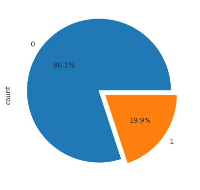

```python
# How many defaulters
perc_default = data['BAD'].value_counts(normalize=True)
print(f'The percentage of defaulters in the data is {perc_default*100} %')
data['BAD'].value_counts().plot(kind='pie',explode=[0.1,0],autopct="%1.1f%%")
plt.plot()
```

Observations:

20% of the clients in the dataset are defaulter on their loans (BAD=1).  
80% of the clients have successfully repaid their loans or are not defaulter (BAD=0).

```python
data.head(1)
```

|  | BAD | LOAN | MORTDUE | VALUE | REASON | JOB | YOJ | DEROG | DELINQ | CLAGE | NINQ | CLNO | DEBTINC |
| --- | --- | --- | --- | --- | --- | --- | --- | --- | --- | --- | --- | --- | --- |
| 0 | 1 | 1100 | 25,860.00 | 39,025.00 | HomeImp | Other | 10.50 | 0.00 | 0.00 | 94.37 | 1.00 | 9.00 | NaN |

```python
print(data['REASON'].value_counts(normalize=True))
```

```
REASON
DebtCon   0.69
HomeImp   0.31
Name: proportion, dtype: float64
```

```python
def show_value_counts(col):
    print(col)
    value_counts = data[col].value_counts()
    percentage = value_counts / len(data) * 100
    #percentage = value_counts(normalize=True)
    result_df = pd.DataFrame({'Value': value_counts.index, 'Count': value_counts, 'Percentage': percentage})
    result_df = result_df.sort_values(by='Value')
    print(result_df)
    print('--------------------------')
    generate_pie_plot(result_df)


def generate_pie_plot(data_frame):
    plt.figure(figsize=(6, 5))
    plt.pie(data_frame['Count'], labels=data_frame['Value'], autopct='%1.1f%%')
    plt.axis('equal')
    plt.show()
```

```
REASON
           Value  Count  Percentage
REASON
DebtCon  DebtCon   3928       65.91
HomeImp  HomeImp   1780       29.87
--------------------------
```

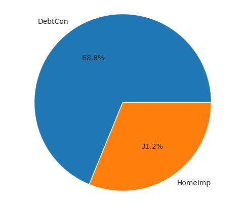

```python
#Show unique categories in the REASON variable
show_value_counts('REASON')
```

**Observations**:

```
JOB
           Value  Count  Percentage
JOB
Mgr          Mgr    767       12.87
Office    Office    948       15.91
Other      Other   2388       40.07
ProfExe  ProfExe   1276       21.41
Sales      Sales    109        1.83
Self        Self    193        3.24
--------------------------
```

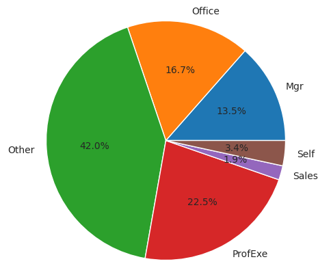

```python
#Show unique categories in the REASON variable
show_value_counts('JOB')
```

**Observations**:

## **Numerical Features representation**

```python
data['DEBTINC'].skew()
```

```
np.float64(2.8523534162154887)
```

```python
# Analyzing the summary statistics for numerical variables

num_cols = ['LOAN', 'MORTDUE', 'VALUE', 'YOJ', 'DEROG', 'DELINQ', 'CLAGE', 'NINQ', 'CLNO', 'DEBTINC']
data[num_cols].describe().T
```

|  | count | mean | std | min | 25% | 50% | 75% | max |
| --- | --- | --- | --- | --- | --- | --- | --- | --- |
| LOAN | 5,960.00 | 18,607.97 | 11,207.48 | 1,100.00 | 11,100.00 | 16,300.00 | 23,300.00 | 89,900.00 |
| MORTDUE | 5,442.00 | 73,760.82 | 44,457.61 | 2,063.00 | 46,276.00 | 65,019.00 | 91,488.00 | 399,550.00 |
| VALUE | 5,848.00 | 101,776.05 | 57,385.78 | 8,000.00 | 66,075.50 | 89,235.50 | 119,824.25 | 855,909.00 |
| YOJ | 5,445.00 | 8.92 | 7.57 | 0.00 | 3.00 | 7.00 | 13.00 | 41.00 |
| DEROG | 5,252.00 | 0.25 | 0.85 | 0.00 | 0.00 | 0.00 | 0.00 | 10.00 |
| DELINQ | 5,380.00 | 0.45 | 1.13 | 0.00 | 0.00 | 0.00 | 0.00 | 15.00 |
| CLAGE | 5,652.00 | 179.77 | 85.81 | 0.00 | 115.12 | 173.47 | 231.56 | 1,168.23 |
| NINQ | 5,450.00 | 1.19 | 1.73 | 0.00 | 0.00 | 1.00 | 2.00 | 17.00 |
| CLNO | 5,738.00 | 21.30 | 10.14 | 0.00 | 15.00 | 20.00 | 26.00 | 71.00 |
| DEBTINC | 4,693.00 | 33.78 | 8.60 | 0.52 | 29.14 | 34.82 | 39.00 | 203.31 |

```python
data.head(3)
```

|  | BAD | LOAN | MORTDUE | VALUE | REASON | JOB | YOJ | DEROG | DELINQ | CLAGE | NINQ | CLNO | DEBTINC |
| --- | --- | --- | --- | --- | --- | --- | --- | --- | --- | --- | --- | --- | --- |
| 0 | 1 | 1100 | 25,860.00 | 39,025.00 | HomeImp | Other | 10.50 | 0.00 | 0.00 | 94.37 | 1.00 | 9.00 | NaN |
| 1 | 1 | 1300 | 70,053.00 | 68,400.00 | HomeImp | Other | 7.00 | 0.00 | 2.00 | 121.83 | 0.00 | 14.00 | NaN |
| 2 | 1 | 1500 | 13,500.00 | 16,700.00 | HomeImp | Other | 4.00 | 0.00 | 0.00 | 149.47 | 1.00 | 10.00 | NaN |

```
LOAN
Skew : 2.02
```

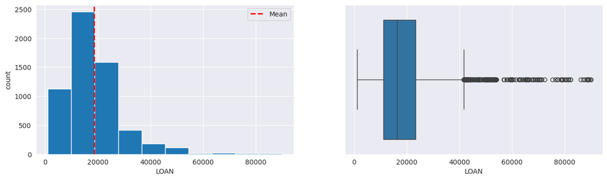

```
MORTDUE
Skew : 1.81
```

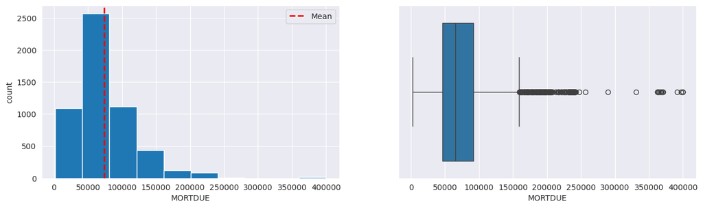

```
VALUE
Skew : 3.05
```

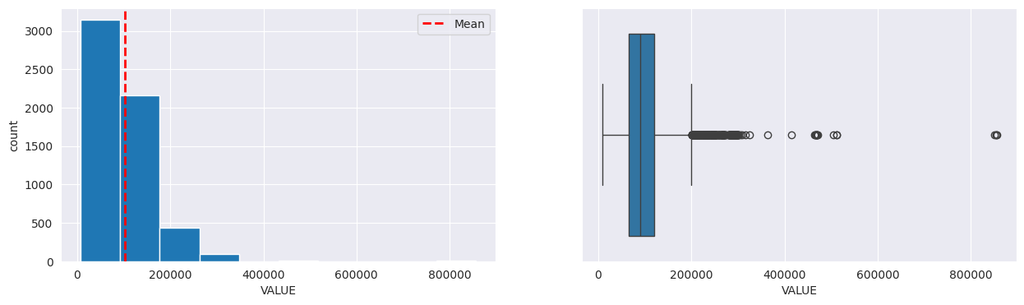

```
YOJ
Skew : 0.99
```

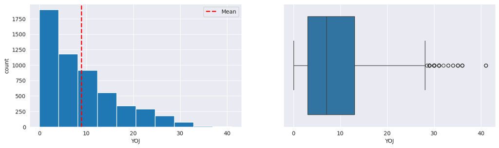

```
DEROG
Skew : 5.32
```

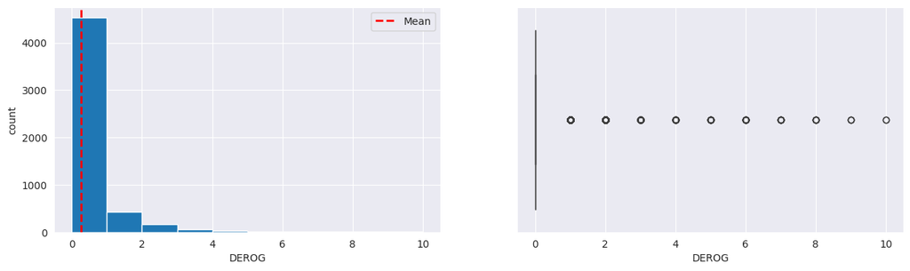

```
DELINQ
Skew : 4.02
```

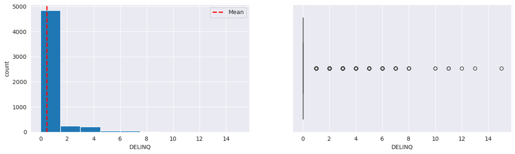

```
CLAGE
Skew : 1.34
```

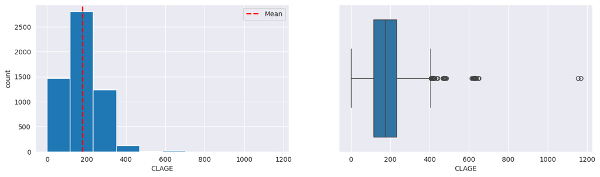

```
NINQ
Skew : 2.62
```

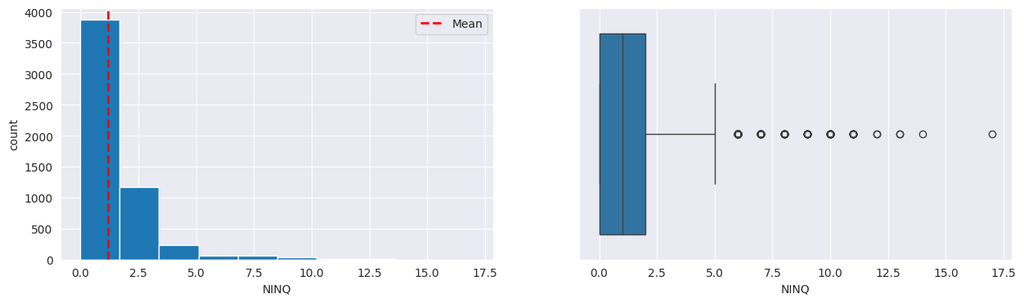

```
CLNO
Skew : 0.78
```

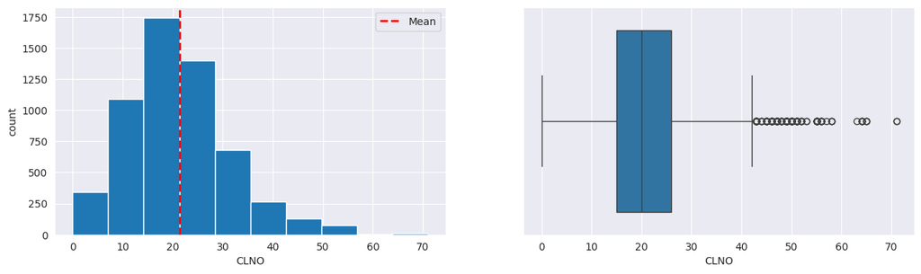

```
DEBTINC
Skew : 2.85
```

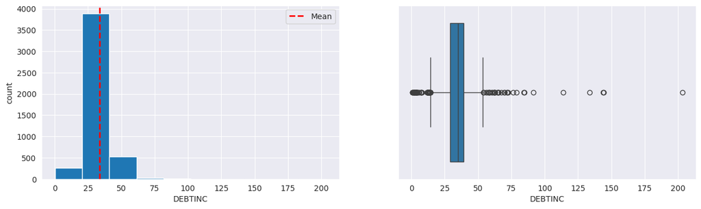

```python
#histogram and boxplot of numerical variables
for feature in num_cols:
    print(feature)

    print('Skew :',round(data[feature].skew(), 2))

    plt.figure(figsize = (15, 4))

    plt.subplot(1, 2, 1)
    # Plotting histogram
    data[feature].hist(bins = 10, grid = True)
    # Adding a vertical line for the mean
    plt.axvline(data[feature].mean(), color='red', linestyle='dashed', linewidth=2, label='Mean')
    plt.legend()


    plt.ylabel('count')
    plt.xlabel(feature)
    plt.subplot(1, 2, 2)

    sns.boxplot(x = data[feature])

    plt.show()
```

**Observations**:

- **LOAN, MORTDUE, VALUE, CLNO, DEBTINC** , all these features are right skewed. This shows that variables have outliers. Maximum number of people have takken loan amount lower than 30000. Some of the Loan amount is as high as about 100000.
- **DEBTINC** normal shape distribution that shows outliers on the right and left ends.
- The variable **LOAN** has a skewed distribution to the right with lot of big outliers compared to the mean. Most of the loan amount is below 30000 but there are a few loans for significantly larger amounts.
- The variable **YOJ** is very skewed to the right and has a few outliers.

### **Bivariate Analysis**

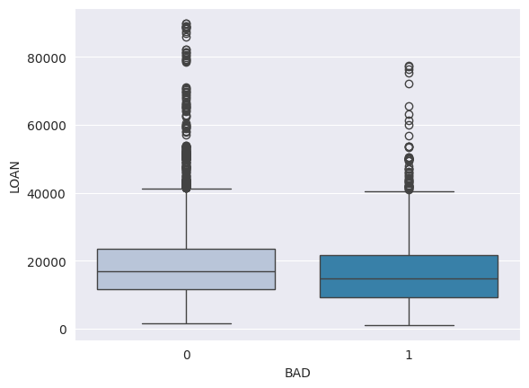

```python
#Analyze BAD vs Loan
sns.boxplot(x=data["BAD"],y=data['LOAN'],palette="PuBu")
```

**Observation** The box plot suggests that the clients who defaulted on their loans tend to have lower loan amounts than those who have did not default. However, there is overlap in the distributions, and both groups have outliers with higher loan amounts.

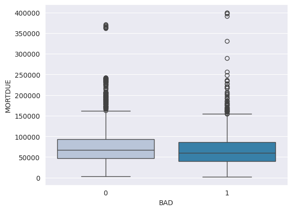

```python
#Analyze BAD vs MORTDUE
sns.boxplot(x=data["BAD"],y=data['MORTDUE'],palette="PuBu")
```

**Observation**

Both type of client (defaulted or not) have the same amount due on the existing mortgage.

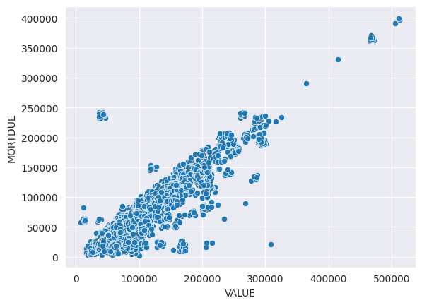

```python
#scatterplot VALUE vs MORTDUE
sns.scatterplot(x=data["VALUE"],y=data['MORTDUE'],palette="PuBu")
```

**Oservation :** There is a positive correlation between mortdue and Value. The current value of the property ('VALUE') increases, the amount due on the existing mortgage ('MORTDUE') also tends to increase

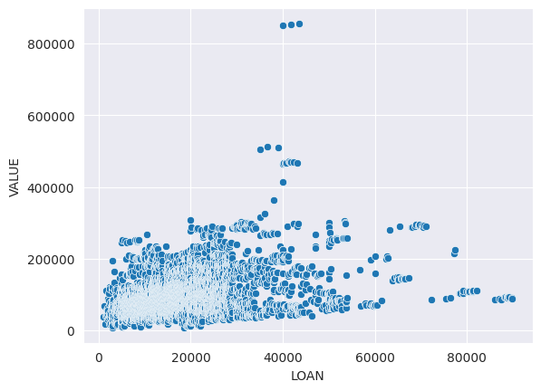

```python
#scatterplot VALUE vs LOAN
sns.scatterplot(x=data["LOAN"],y=data['VALUE'],palette="PuBu")
```

There doesn't appear to be a strong linear correlation between the loan amount ('LOAN') and the current value of the property ('VALUE'). The points are quite scattered and there is no clear pattern.So this suggests that the value of the property is not a sole determinant of the loan amount, and other factors likely play a significant role in how much loan is approved.

### **Multivariate Analysis**

```python
### Function to plot stacked bar charts for categorical columns
def stacked_barplot(data, predictor, target):
    """
    Print the category counts and plot a stacked bar chart

    data: dataframe
    predictor: independent variable
    target: target variable
    """
    count = data[predictor].nunique()
    sorter = data[target].value_counts().index[-1]
    tab1 = pd.crosstab(data[predictor], data[target], margins=True).sort_values(
        by=sorter, ascending=False
    )
    print(tab1)
    print("-" * 120)
    tab = pd.crosstab(data[predictor], data[target], normalize="index").sort_values(
        by=sorter, ascending=False
    )
    tab.plot(kind="bar", stacked=True, figsize=(count + 5, 5))
    plt.legend(
        loc="lower left", frameon=False,
    )
    plt.legend(loc="upper left", bbox_to_anchor=(1, 1))
    plt.xticks(rotation=0)
    plt.show()
```

```
BAD         0     1   All
REASON
All      4567  1141  5708
DebtCon  3183   745  3928
HomeImp  1384   396  1780
------------------------------------------------------------------------------------------------------------------------
```

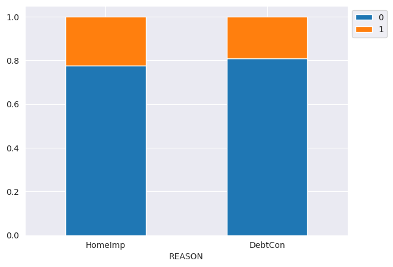

```python
stacked_barplot(data, "REASON", "BAD")
```

**Observation**:

Both reason debt consolidation or home improvement have no such difference on loan defaulter or not

## **MultiVariate Analysis**

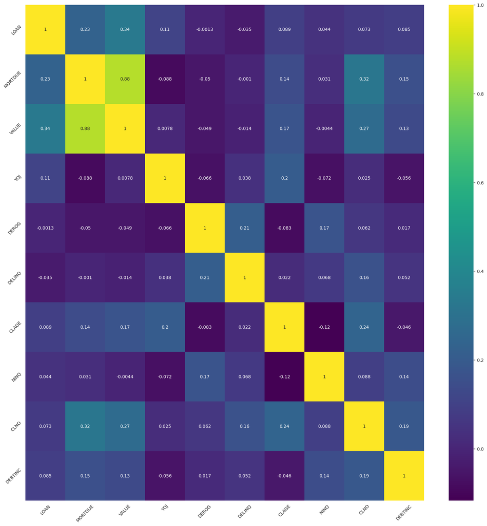

```python
# Create a figure and plot the heatmap
plt.figure(figsize=(20, 20))
heat_map = sns.heatmap(data.corr(numeric_only=True), annot=True, cmap="viridis")
heat_map.set_yticklabels(heat_map.get_yticklabels(), rotation=45)
heat_map.set_xticklabels(heat_map.get_xticklabels(), rotation=45)
plt.show()
```

## Treating Outliers

```python
#function to treat outliers
def treat_outliers(df,col):
    '''
    treats outliers in a varaible
    col: str, name of the numerical varaible
    df: data frame

    '''

    Q1=df[col].quantile(q = .25) # 25th quantile

    Q3=df[col].quantile(q = .75)  # 75th quantile
    IQR = Q3-Q1   # IQR Range

    Lower_Whisker = Q1 - 1.5*IQR  #define lower whisker
    Upper_Whisker = Q3 + 1.5*IQR  # define upper Whisker
    df[col] = np.clip(df[col], Lower_Whisker, Upper_Whisker) # all the values samller than Lower_Whisker will be assigned value of Lower_whisker
                                                            # and all the values above upper_whishker will be assigned value of upper_Whisker
    return df

def treat_outliers_all(df, col_list):
    '''
    treat outlier in all numerical varaibles
    col_list: list of numerical varaibles
    df: data frame
    '''
    for c in col_list:
        df = treat_outliers(df,c)

    return df
```

```python
#copy data
df_raw = data.copy()

numerical_col = df_raw.select_dtypes(include=np.number).columns.tolist()# getting list of numerical columns

df = treat_outliers_all(df_raw,numerical_col)
```

```python
df
```

|  | BAD | LOAN | MORTDUE | VALUE | REASON | JOB | YOJ | DEROG | DELINQ | CLAGE | NINQ | CLNO | DEBTINC |
| --- | --- | --- | --- | --- | --- | --- | --- | --- | --- | --- | --- | --- | --- |
| 0 | 1 | 1100 | 25,860.00 | 39,025.00 | HomeImp | Other | 10.50 | 0.00 | 0.00 | 94.37 | 1.00 | 9.00 | NaN |
| 1 | 1 | 1300 | 70,053.00 | 68,400.00 | HomeImp | Other | 7.00 | 0.00 | 0.00 | 121.83 | 0.00 | 14.00 | NaN |
| 2 | 1 | 1500 | 13,500.00 | 16,700.00 | HomeImp | Other | 4.00 | 0.00 | 0.00 | 149.47 | 1.00 | 10.00 | NaN |
| 3 | 1 | 1500 | NaN | NaN | NaN | NaN | NaN | NaN | NaN | NaN | NaN | NaN | NaN |
| 4 | 0 | 1700 | 97,800.00 | 112,000.00 | HomeImp | Office | 3.00 | 0.00 | 0.00 | 93.33 | 0.00 | 14.00 | NaN |
| ... | ... | ... | ... | ... | ... | ... | ... | ... | ... | ... | ... | ... | ... |
| 5955 | 0 | 41600 | 57,264.00 | 90,185.00 | DebtCon | Other | 16.00 | 0.00 | 0.00 | 221.81 | 0.00 | 16.00 | 36.11 |
| 5956 | 0 | 41600 | 54,576.00 | 92,937.00 | DebtCon | Other | 16.00 | 0.00 | 0.00 | 208.69 | 0.00 | 15.00 | 35.86 |
| 5957 | 0 | 41600 | 54,045.00 | 92,924.00 | DebtCon | Other | 15.00 | 0.00 | 0.00 | 212.28 | 0.00 | 15.00 | 35.56 |
| 5958 | 0 | 41600 | 50,370.00 | 91,861.00 | DebtCon | Other | 14.00 | 0.00 | 0.00 | 213.89 | 0.00 | 16.00 | 34.34 |
| 5959 | 0 | 41600 | 48,811.00 | 88,934.00 | DebtCon | Other | 15.00 | 0.00 | 0.00 | 219.60 | 0.00 | 16.00 | 34.57 |

5960 rows × 13 columns

## Treating Missing Values

**Adding new columns in the dataset for each column which has missing values**

```python
#For each column we create a binary flag for the row, if there is missing value in the row, then 1 else 0.
def add_binary_flag(df,col):
    '''
    df: It is the dataframe
    col: it is column which has missing values
    It returns a dataframe which has binary falg for missing values in column col
    '''
    new_col = str(col)
    new_col += '_missing_values_flag'
    df[new_col] = df[col].isna().astype(int)
    return df
```

```python
# list of columns that has missing values in it
missing_col = [col for col in df.columns if df[col].isnull().any()]

for colmn in missing_col:
    add_binary_flag(df,colmn)
```

**Filling missing values in numerical columns with median and mode in categorical variables**

```python
df
```

|  | BAD | LOAN | MORTDUE | VALUE | REASON | JOB | YOJ | DEROG | DELINQ | CLAGE | ... | VALUE_missing_values_flag | REASON_missing_values_flag | JOB_missing_values_flag | YOJ_missing_values_flag | DEROG_missing_values_flag | DELINQ_missing_values_flag | CLAGE_missing_values_flag | NINQ_missing_values_flag | CLNO_missing_values_flag | DEBTINC_missing_values_flag |
| --- | --- | --- | --- | --- | --- | --- | --- | --- | --- | --- | --- | --- | --- | --- | --- | --- | --- | --- | --- | --- | --- |
| 0 | 1 | 1100 | 25,860.00 | 39,025.00 | HomeImp | Other | 10.50 | 0.00 | 0.00 | 94.37 | ... | 0 | 0 | 0 | 0 | 0 | 0 | 0 | 0 | 0 | 1 |
| 1 | 1 | 1300 | 70,053.00 | 68,400.00 | HomeImp | Other | 7.00 | 0.00 | 0.00 | 121.83 | ... | 0 | 0 | 0 | 0 | 0 | 0 | 0 | 0 | 0 | 1 |
| 2 | 1 | 1500 | 13,500.00 | 16,700.00 | HomeImp | Other | 4.00 | 0.00 | 0.00 | 149.47 | ... | 0 | 0 | 0 | 0 | 0 | 0 | 0 | 0 | 0 | 1 |
| 3 | 1 | 1500 | NaN | NaN | NaN | NaN | NaN | NaN | NaN | NaN | ... | 1 | 1 | 1 | 1 | 1 | 1 | 1 | 1 | 1 | 1 |
| 4 | 0 | 1700 | 97,800.00 | 112,000.00 | HomeImp | Office | 3.00 | 0.00 | 0.00 | 93.33 | ... | 0 | 0 | 0 | 0 | 0 | 0 | 0 | 0 | 0 | 1 |
| ... | ... | ... | ... | ... | ... | ... | ... | ... | ... | ... | ... | ... | ... | ... | ... | ... | ... | ... | ... | ... | ... |
| 5955 | 0 | 41600 | 57,264.00 | 90,185.00 | DebtCon | Other | 16.00 | 0.00 | 0.00 | 221.81 | ... | 0 | 0 | 0 | 0 | 0 | 0 | 0 | 0 | 0 | 0 |
| 5956 | 0 | 41600 | 54,576.00 | 92,937.00 | DebtCon | Other | 16.00 | 0.00 | 0.00 | 208.69 | ... | 0 | 0 | 0 | 0 | 0 | 0 | 0 | 0 | 0 | 0 |
| 5957 | 0 | 41600 | 54,045.00 | 92,924.00 | DebtCon | Other | 15.00 | 0.00 | 0.00 | 212.28 | ... | 0 | 0 | 0 | 0 | 0 | 0 | 0 | 0 | 0 | 0 |
| 5958 | 0 | 41600 | 50,370.00 | 91,861.00 | DebtCon | Other | 14.00 | 0.00 | 0.00 | 213.89 | ... | 0 | 0 | 0 | 0 | 0 | 0 | 0 | 0 | 0 | 0 |
| 5959 | 0 | 41600 | 48,811.00 | 88,934.00 | DebtCon | Other | 15.00 | 0.00 | 0.00 | 219.60 | ... | 0 | 0 | 0 | 0 | 0 | 0 | 0 | 0 | 0 | 0 |

5960 rows × 24 columns

**Adding new columns in the dataset for each column which has missing values**

```python
#  Treating Missing values in numerical columns with median and mode in categorical variables
# Select numeric columns.
num_data = df.select_dtypes('number')

# Selecting string and object columns.
cat_data = df.select_dtypes('category').columns.tolist() #df.select_dtypes('object')

# Filling numeric columns with median.
df[num_data.columns] = num_data.fillna(num_data.median())

# Filling object columns with mode.
for column in cat_data:
    mode = df[column].mode()[0]
    df[column].fillna(df[column].mode()[0], inplace=True)
```

## **Important Insights from EDA**

What are the the most important observations and insights from the data based on the EDA performed?

```python
df.isnull().sum()
```

|  | 0 |
| --- | --- |
| BAD | 0 |
| LOAN | 0 |
| MORTDUE | 0 |
| VALUE | 0 |
| REASON | 0 |
| JOB | 0 |
| YOJ | 0 |
| DEROG | 0 |
| DELINQ | 0 |
| CLAGE | 0 |
| NINQ | 0 |
| CLNO | 0 |
| DEBTINC | 0 |
| MORTDUE_missing_values_flag | 0 |
| VALUE_missing_values_flag | 0 |
| REASON_missing_values_flag | 0 |
| JOB_missing_values_flag | 0 |
| YOJ_missing_values_flag | 0 |
| DEROG_missing_values_flag | 0 |
| DELINQ_missing_values_flag | 0 |
| CLAGE_missing_values_flag | 0 |
| NINQ_missing_values_flag | 0 |
| CLNO_missing_values_flag | 0 |
| DEBTINC_missing_values_flag | 0 |

**dtype:** int64

```python
df.head()
```

|  | BAD | LOAN | MORTDUE | VALUE | REASON | JOB | YOJ | DEROG | DELINQ | CLAGE | ... | VALUE_missing_values_flag | REASON_missing_values_flag | JOB_missing_values_flag | YOJ_missing_values_flag | DEROG_missing_values_flag | DELINQ_missing_values_flag | CLAGE_missing_values_flag | NINQ_missing_values_flag | CLNO_missing_values_flag | DEBTINC_missing_values_flag |
| --- | --- | --- | --- | --- | --- | --- | --- | --- | --- | --- | --- | --- | --- | --- | --- | --- | --- | --- | --- | --- | --- |
| 0 | 1 | 1100 | 25,860.00 | 39,025.00 | HomeImp | Other | 10.50 | 0.00 | 0.00 | 94.37 | ... | 0 | 0 | 0 | 0 | 0 | 0 | 0 | 0 | 0 | 1 |
| 1 | 1 | 1300 | 70,053.00 | 68,400.00 | HomeImp | Other | 7.00 | 0.00 | 0.00 | 121.83 | ... | 0 | 0 | 0 | 0 | 0 | 0 | 0 | 0 | 0 | 1 |
| 2 | 1 | 1500 | 13,500.00 | 16,700.00 | HomeImp | Other | 4.00 | 0.00 | 0.00 | 149.47 | ... | 0 | 0 | 0 | 0 | 0 | 0 | 0 | 0 | 0 | 1 |
| 3 | 1 | 1500 | 65,019.00 | 89,235.50 | DebtCon | Other | 7.00 | 0.00 | 0.00 | 173.47 | ... | 1 | 1 | 1 | 1 | 1 | 1 | 1 | 1 | 1 | 1 |
| 4 | 0 | 1700 | 97,800.00 | 112,000.00 | HomeImp | Office | 3.00 | 0.00 | 0.00 | 93.33 | ... | 0 | 0 | 0 | 0 | 0 | 0 | 0 | 0 | 0 | 1 |

5 rows × 24 columns

```python
df.tail()
```

|  | BAD | LOAN | MORTDUE | VALUE | REASON | JOB | YOJ | DEROG | DELINQ | CLAGE | ... | VALUE_missing_values_flag | REASON_missing_values_flag | JOB_missing_values_flag | YOJ_missing_values_flag | DEROG_missing_values_flag | DELINQ_missing_values_flag | CLAGE_missing_values_flag | NINQ_missing_values_flag | CLNO_missing_values_flag | DEBTINC_missing_values_flag |
| --- | --- | --- | --- | --- | --- | --- | --- | --- | --- | --- | --- | --- | --- | --- | --- | --- | --- | --- | --- | --- | --- |
| 5955 | 0 | 41600 | 57,264.00 | 90,185.00 | DebtCon | Other | 16.00 | 0.00 | 0.00 | 221.81 | ... | 0 | 0 | 0 | 0 | 0 | 0 | 0 | 0 | 0 | 0 |
| 5956 | 0 | 41600 | 54,576.00 | 92,937.00 | DebtCon | Other | 16.00 | 0.00 | 0.00 | 208.69 | ... | 0 | 0 | 0 | 0 | 0 | 0 | 0 | 0 | 0 | 0 |
| 5957 | 0 | 41600 | 54,045.00 | 92,924.00 | DebtCon | Other | 15.00 | 0.00 | 0.00 | 212.28 | ... | 0 | 0 | 0 | 0 | 0 | 0 | 0 | 0 | 0 | 0 |
| 5958 | 0 | 41600 | 50,370.00 | 91,861.00 | DebtCon | Other | 14.00 | 0.00 | 0.00 | 213.89 | ... | 0 | 0 | 0 | 0 | 0 | 0 | 0 | 0 | 0 | 0 |
| 5959 | 0 | 41600 | 48,811.00 | 88,934.00 | DebtCon | Other | 15.00 | 0.00 | 0.00 | 219.60 | ... | 0 | 0 | 0 | 0 | 0 | 0 | 0 | 0 | 0 | 0 |

5 rows × 24 columns

```python
df.info()
```

```
<class 'pandas.core.frame.DataFrame'>
RangeIndex: 5960 entries, 0 to 5959
Data columns (total 24 columns):
 #   Column                       Non-Null Count  Dtype
---  ------                       --------------  -----
 0   BAD                          5960 non-null   category
 1   LOAN                         5960 non-null   int64
 2   MORTDUE                      5960 non-null   float64
 3   VALUE                        5960 non-null   float64
 4   REASON                       5960 non-null   category
 5   JOB                          5960 non-null   category
 6   YOJ                          5960 non-null   float64
 7   DEROG                        5960 non-null   float64
 8   DELINQ                       5960 non-null   float64
 9   CLAGE                        5960 non-null   float64
```

[output cut: 16 more lines]

```python
#creating a list of bool features
bool_cols = df.select_dtypes(['bool']).columns.tolist()

#droping missing value flags
X = df.drop(columns = bool_cols)
```

```python
X.head()
```

|  | BAD | LOAN | MORTDUE | VALUE | REASON | JOB | YOJ | DEROG | DELINQ | CLAGE | ... | VALUE_missing_values_flag | REASON_missing_values_flag | JOB_missing_values_flag | YOJ_missing_values_flag | DEROG_missing_values_flag | DELINQ_missing_values_flag | CLAGE_missing_values_flag | NINQ_missing_values_flag | CLNO_missing_values_flag | DEBTINC_missing_values_flag |
| --- | --- | --- | --- | --- | --- | --- | --- | --- | --- | --- | --- | --- | --- | --- | --- | --- | --- | --- | --- | --- | --- |
| 0 | 1 | 1100 | 25,860.00 | 39,025.00 | HomeImp | Other | 10.50 | 0.00 | 0.00 | 94.37 | ... | 0 | 0 | 0 | 0 | 0 | 0 | 0 | 0 | 0 | 1 |
| 1 | 1 | 1300 | 70,053.00 | 68,400.00 | HomeImp | Other | 7.00 | 0.00 | 0.00 | 121.83 | ... | 0 | 0 | 0 | 0 | 0 | 0 | 0 | 0 | 0 | 1 |
| 2 | 1 | 1500 | 13,500.00 | 16,700.00 | HomeImp | Other | 4.00 | 0.00 | 0.00 | 149.47 | ... | 0 | 0 | 0 | 0 | 0 | 0 | 0 | 0 | 0 | 1 |
| 3 | 1 | 1500 | 65,019.00 | 89,235.50 | DebtCon | Other | 7.00 | 0.00 | 0.00 | 173.47 | ... | 1 | 1 | 1 | 1 | 1 | 1 | 1 | 1 | 1 | 1 |
| 4 | 0 | 1700 | 97,800.00 | 112,000.00 | HomeImp | Office | 3.00 | 0.00 | 0.00 | 93.33 | ... | 0 | 0 | 0 | 0 | 0 | 0 | 0 | 0 | 0 | 1 |

5 rows × 24 columns

```python
X.info()
```

```
<class 'pandas.core.frame.DataFrame'>
RangeIndex: 5960 entries, 0 to 5959
Data columns (total 24 columns):
 #   Column                       Non-Null Count  Dtype
---  ------                       --------------  -----
 0   BAD                          5960 non-null   category
 1   LOAN                         5960 non-null   int64
 2   MORTDUE                      5960 non-null   float64
 3   VALUE                        5960 non-null   float64
 4   REASON                       5960 non-null   category
 5   JOB                          5960 non-null   category
 6   YOJ                          5960 non-null   float64
 7   DEROG                        5960 non-null   float64
 8   DELINQ                       5960 non-null   float64
 9   CLAGE                        5960 non-null   float64
```

[output cut: 16 more lines]

## **Model Building - Approach**

- Data preparation
- Partition the data into train and test set
- Build the model
- Fit on the train data
- Tune the model
- Test the model on test set

# **Separating the target variable from other variables**

```python
# Separating the target variable and other variables
Y = X.BAD
X = X.drop(columns = ['BAD'])

# Creating dummy variables for the categorical variables

# Creating the list of columns for which we need to create the dummy variables
to_get_dummies_for = ['REASON', 'JOB']

# Creating dummy variables
X = pd.get_dummies(data = X, columns = to_get_dummies_for, drop_first = True)
```

# **Scaling the data **

**In this case features have different scales, so we will use the Standard Scaler method, which centers and scales the dataset using the Z-Score.**

```python
# Scaling the data

sc = StandardScaler()
X_scaled= sc.fit_transform(X)
X_scaled = pd.DataFrame(X_scaled, columns = X.columns)
```

```python
X_scaled
```

|  | LOAN | MORTDUE | VALUE | YOJ | DEROG | DELINQ | CLAGE | NINQ | CLNO | DEBTINC | ... | CLAGE_missing_values_flag | NINQ_missing_values_flag | CLNO_missing_values_flag | DEBTINC_missing_values_flag | REASON_HomeImp | JOB_Office | JOB_Other | JOB_ProfExe | JOB_Sales | JOB_Self |
| --- | --- | --- | --- | --- | --- | --- | --- | --- | --- | --- | --- | --- | --- | --- | --- | --- | --- | --- | --- | --- | --- |
| 0 | -1.83 | -1.27 | -1.33 | 0.25 | 0.00 | 0.00 | -1.07 | -0.07 | -1.30 | 0.14 | ... | -0.23 | -0.31 | -0.20 | 1.92 | 1.53 | -0.43 | 1.11 | -0.52 | -0.14 | -0.18 |
| 1 | -1.81 | -0.03 | -0.67 | -0.24 | 0.00 | 0.00 | -0.72 | -0.83 | -0.76 | 0.14 | ... | -0.23 | -0.31 | -0.20 | 1.92 | 1.53 | -0.43 | 1.11 | -0.52 | -0.14 | -0.18 |
| 2 | -1.79 | -1.62 | -1.83 | -0.66 | 0.00 | 0.00 | -0.37 | -0.07 | -1.19 | 0.14 | ... | -0.23 | -0.31 | -0.20 | 1.92 | 1.53 | -0.43 | 1.11 | -0.52 | -0.14 | -0.18 |
| 3 | -1.79 | -0.17 | -0.20 | -0.24 | 0.00 | 0.00 | -0.06 | -0.07 | -0.11 | 0.14 | ... | 4.28 | 3.27 | 5.08 | 1.92 | -0.65 | -0.43 | 1.11 | -0.52 | -0.14 | -0.18 |
| 4 | -1.77 | 0.75 | 0.31 | -0.80 | 0.00 | 0.00 | -1.08 | -0.83 | -0.76 | 0.14 | ... | -0.23 | -0.31 | -0.20 | 1.92 | 1.53 | 2.30 | -0.90 | -0.52 | -0.14 | -0.18 |
| ... | ... | ... | ... | ... | ... | ... | ... | ... | ... | ... | ... | ... | ... | ... | ... | ... | ... | ... | ... | ... | ... |
| 5955 | 2.55 | -0.39 | -0.18 | 1.02 | 0.00 | 0.00 | 0.55 | -0.83 | -0.54 | 0.34 | ... | -0.23 | -0.31 | -0.20 | -0.52 | -0.65 | -0.43 | 1.11 | -0.52 | -0.14 | -0.18 |
| 5956 | 2.55 | -0.46 | -0.12 | 1.02 | 0.00 | 0.00 | 0.39 | -0.83 | -0.65 | 0.31 | ... | -0.23 | -0.31 | -0.20 | -0.52 | -0.65 | -0.43 | 1.11 | -0.52 | -0.14 | -0.18 |
| 5957 | 2.55 | -0.48 | -0.12 | 0.88 | 0.00 | 0.00 | 0.43 | -0.83 | -0.65 | 0.26 | ... | -0.23 | -0.31 | -0.20 | -0.52 | -0.65 | -0.43 | 1.11 | -0.52 | -0.14 | -0.18 |
| 5958 | 2.55 | -0.58 | -0.15 | 0.74 | 0.00 | 0.00 | 0.45 | -0.83 | -0.54 | 0.07 | ... | -0.23 | -0.31 | -0.20 | -0.52 | -0.65 | -0.43 | 1.11 | -0.52 | -0.14 | -0.18 |
| 5959 | 2.55 | -0.62 | -0.21 | 0.88 | 0.00 | 0.00 | 0.53 | -0.83 | -0.54 | 0.10 | ... | -0.23 | -0.31 | -0.20 | -0.52 | -0.65 | -0.43 | 1.11 | -0.52 | -0.14 | -0.18 |

5960 rows × 27 columns

# **Splitting the data into 70% train and 30% test set**

**The data is unbalanced ( approx 80% is non defaulted and approx 20% is defaulted). For this reason, we will use stratified sampling technique to ensure that relative class frequencies are approximately preserved in each train and validation fold.**

```python
x_train, x_test, y_train, y_test = train_test_split(X_scaled, Y, test_size = 0.3, random_state = 42, stratify = Y)
```

## **Model Evaluation Criterion**

```python
#creating metric function
def metrics_score(actual, predicted):
    print(classification_report(actual, predicted))
    cm = confusion_matrix(actual, predicted)

    group_names = ['True Neg','False Pos','False Neg','True Pos']
    group_counts = ["{0:0.0f}".format(value) for value in cm.flatten()]
    group_percentages = ["{0:.2%}".format(value) for value in cm.flatten()/np.sum(cm)]
    labels = [f"{v1}\n{v2}\n{v3}" for v1, v2, v3 in zip(group_names,group_counts,group_percentages)]
    labels = np.asarray(labels).reshape(2,2)
    plt.figure(figsize=(6,4))
    sns.heatmap(cm, annot=labels, fmt='', xticklabels=['Not Eligible', 'Eligible'], yticklabels=['Not Eligible', 'Eligible'],cmap='Blues')
    plt.ylabel('Actual')
    plt.xlabel('Predicted')
    plt.show()
```

```python
def model_performance_classification(model, predictors, target):
    """
    Function to compute different metrics to check classification model performance
    model: classifier
    predictors: independent variables
    target: dependent variable
    """

    # Predicting using the independent variables
    pred = model.predict(predictors)
    recall = recall_score(target, pred,average = 'binary' , pos_label= 1)                 # To compute recall
    precision = precision_score(target, pred, average = 'binary', pos_label = 1)              # To compute precision
    acc = accuracy_score(target, pred)                                 # To compute accuracy score

    # Creating a dataframe of metrics
    df_perf = pd.DataFrame(
        {
            "Precision":  precision,
            "Recall":  recall,
            "Accuracy": acc,
        },

        index = [1],
    )

    return df_perf
```

### **Logistic Regression**

Logistic Regression is a supervised learning algorithm, generally used for binary classification problems, i.e., where the dependent variable is categorical and has only two possible values. In logistic regression, we use the sigmoid function to calculate the probability of an event Y, given some features X as:

```
              P(Y)=1/(1 + exp(-X))
```

```python
# Defining Logistics regression model
lg = LogisticRegression()

# Fitting the model
lg.fit(x_train, y_train)
```

```
LogisticRegression()
```

Checking the performance on the train dataset

```
              precision    recall  f1-score   support

           0       0.91      0.94      0.92      3340
           1       0.73      0.62      0.67       832

    accuracy                           0.88      4172
   macro avg       0.82      0.78      0.80      4172
weighted avg       0.87      0.88      0.87      4172
```

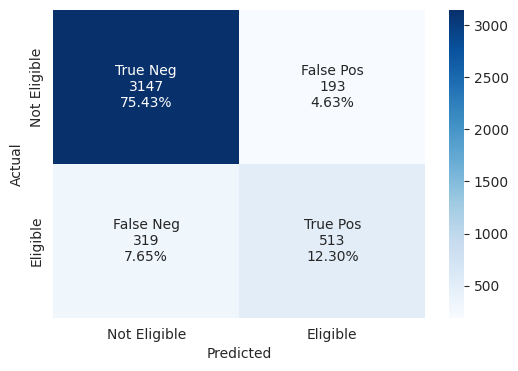

```python
#Predicting for train set
y_pred_train = lg.predict(x_train)

#checking the performance on the train dataset
metrics_score(y_train, y_pred_train)
```

Checking the performance on the test dataset

```
              precision    recall  f1-score   support

           0       0.90      0.94      0.92      1431
           1       0.72      0.59      0.65       357

    accuracy                           0.87      1788
   macro avg       0.81      0.77      0.78      1788
weighted avg       0.87      0.87      0.87      1788
```

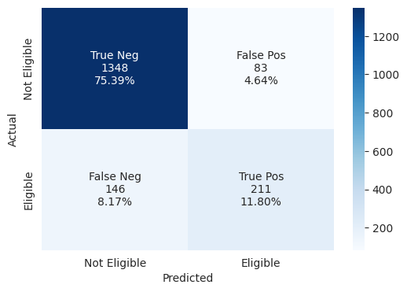

```python
y_pred_test = lg.predict(x_test)

metrics_score(y_test, y_pred_test)
```

```python
lg_test = model_performance_classification(lg, x_test, y_test)
lg_test
```

|  | Precision | Recall | Accuracy |
| --- | --- | --- | --- |
| 1 | 0.72 | 0.59 | 0.87 |

Checking the coefficients, and check which variables are important and how they affect the process of loan approval

```python
# Printing the coefficients of logistic regression

cols = X_scaled.columns

coef_lg = lg.coef_

pd.DataFrame(coef_lg,columns = cols).T.sort_values(by = 0, ascending = False)
```

|  | 0 |
| --- | --- |
| DEBTINC_missing_values_flag | 1.17 |
| VALUE_missing_values_flag | 0.77 |
| DEBTINC | 0.70 |
| CLNO_missing_values_flag | 0.27 |
| CLAGE_missing_values_flag | 0.26 |
| NINQ | 0.25 |
| NINQ_missing_values_flag | 0.17 |
| JOB_Sales | 0.15 |
| MORTDUE_missing_values_flag | 0.12 |
| VALUE | 0.10 |
| REASON_HomeImp | 0.08 |
| JOB_Self | 0.07 |
| CLNO | 0.03 |
| DEROG | 0.00 |
| DELINQ | 0.00 |
| REASON_missing_values_flag | -0.01 |
| JOB_Other | -0.03 |
| YOJ | -0.05 |
| LOAN | -0.11 |
| JOB_ProfExe | -0.13 |
| YOJ_missing_values_flag | -0.15 |
| MORTDUE | -0.25 |
| JOB_Office | -0.28 |
| DEROG_missing_values_flag | -0.37 |
| DELINQ_missing_values_flag | -0.42 |
| CLAGE | -0.48 |
| JOB_missing_values_flag | -0.55 |

# **Observations**:

- **Features which positively affect on the defaulted rate are: **

  DEBTINC NINQ
- Features which negatively affect on the defaulted rate are:

  MORTDUE CLAGE  
  The coefficients of the logistic regression model give us the log of odds, which is hard to interpret in the real world. We can convert the log of odds into odds by taking its exponential.

```python
odds = np.exp(lg.coef_[0]) # Finding the odds

# Adding the odds to a DataFrame and sorting the values
pd.DataFrame(odds, x_train.columns, columns = ['odds']).sort_values(by = 'odds', ascending = False)
```

|  | odds |
| --- | --- |
| DEBTINC_missing_values_flag | 3.21 |
| VALUE_missing_values_flag | 2.16 |
| DEBTINC | 2.02 |
| CLNO_missing_values_flag | 1.31 |
| CLAGE_missing_values_flag | 1.30 |
| NINQ | 1.28 |
| NINQ_missing_values_flag | 1.18 |
| JOB_Sales | 1.16 |
| MORTDUE_missing_values_flag | 1.12 |
| VALUE | 1.10 |
| REASON_HomeImp | 1.09 |
| JOB_Self | 1.07 |
| CLNO | 1.03 |
| DEROG | 1.00 |
| DELINQ | 1.00 |
| REASON_missing_values_flag | 0.99 |
| JOB_Other | 0.97 |
| YOJ | 0.95 |
| LOAN | 0.89 |
| JOB_ProfExe | 0.88 |
| YOJ_missing_values_flag | 0.86 |
| MORTDUE | 0.78 |
| JOB_Office | 0.76 |
| DEROG_missing_values_flag | 0.69 |
| DELINQ_missing_values_flag | 0.66 |
| CLAGE | 0.62 |
| JOB_missing_values_flag | 0.58 |

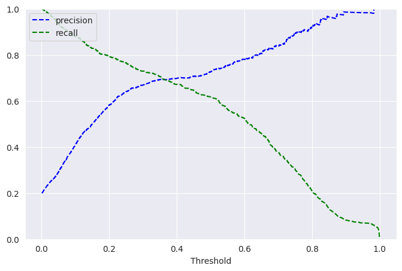

```python
y_scores_lg = lg.predict_proba(x_train) # predict_proba gives the probability of each observation belonging to each class


precisions_lg, recalls_lg, thresholds_lg = precision_recall_curve(y_train, y_scores_lg[:, 1])

# Plot values of precisions, recalls, and thresholds
plt.figure(figsize = (8,5))

plt.plot(thresholds_lg, precisions_lg[:-1], 'b--', label = 'precision')

plt.plot(thresholds_lg, recalls_lg[:-1], 'g--', label = 'recall')

plt.xlabel('Threshold')

plt.legend(loc = 'upper left')

plt.ylim([0, 1])

plt.show()
```

**Observation**:

We can see that the precision and the recall are balanced for a threshold of about 0.3.

Let's find out the performance of the model at this threshold.

```
              precision    recall  f1-score   support

           0       0.93      0.91      0.92      3340
           1       0.67      0.72      0.70       832

    accuracy                           0.88      4172
   macro avg       0.80      0.82      0.81      4172
weighted avg       0.88      0.88      0.88      4172
```

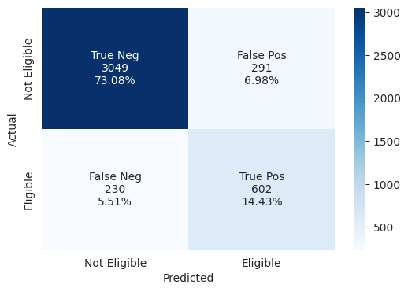

```python
optimal_threshold1 = .31

y_pred_train = lg.predict_proba(x_train)
metrics_score(y_train, y_pred_train[:, 1] > optimal_threshold1)
```

Let's check the test data at .31 threshold

```
              precision    recall  f1-score   support

           0       0.93      0.90      0.91      1431
           1       0.64      0.72      0.68       357

    accuracy                           0.86      1788
   macro avg       0.78      0.81      0.79      1788
weighted avg       0.87      0.86      0.87      1788
```

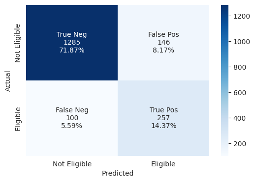

```python
optimal_threshold1 = .31

y_pred_test = lg.predict_proba(x_test)

metrics_score(y_test, y_pred_test[:, 1] > optimal_threshold1)
```

**Observations**:

### Decision Tree

**Data Preparation**

```python
#copying df to another variable
data = df.copy()
```

```python
data
```

|  | BAD | LOAN | MORTDUE | VALUE | REASON | JOB | YOJ | DEROG | DELINQ | CLAGE | ... | VALUE_missing_values_flag | REASON_missing_values_flag | JOB_missing_values_flag | YOJ_missing_values_flag | DEROG_missing_values_flag | DELINQ_missing_values_flag | CLAGE_missing_values_flag | NINQ_missing_values_flag | CLNO_missing_values_flag | DEBTINC_missing_values_flag |
| --- | --- | --- | --- | --- | --- | --- | --- | --- | --- | --- | --- | --- | --- | --- | --- | --- | --- | --- | --- | --- | --- |
| 0 | 1 | 1100 | 25,860.00 | 39,025.00 | HomeImp | Other | 10.50 | 0.00 | 0.00 | 94.37 | ... | 0 | 0 | 0 | 0 | 0 | 0 | 0 | 0 | 0 | 1 |
| 1 | 1 | 1300 | 70,053.00 | 68,400.00 | HomeImp | Other | 7.00 | 0.00 | 0.00 | 121.83 | ... | 0 | 0 | 0 | 0 | 0 | 0 | 0 | 0 | 0 | 1 |
| 2 | 1 | 1500 | 13,500.00 | 16,700.00 | HomeImp | Other | 4.00 | 0.00 | 0.00 | 149.47 | ... | 0 | 0 | 0 | 0 | 0 | 0 | 0 | 0 | 0 | 1 |
| 3 | 1 | 1500 | 65,019.00 | 89,235.50 | DebtCon | Other | 7.00 | 0.00 | 0.00 | 173.47 | ... | 1 | 1 | 1 | 1 | 1 | 1 | 1 | 1 | 1 | 1 |
| 4 | 0 | 1700 | 97,800.00 | 112,000.00 | HomeImp | Office | 3.00 | 0.00 | 0.00 | 93.33 | ... | 0 | 0 | 0 | 0 | 0 | 0 | 0 | 0 | 0 | 1 |
| ... | ... | ... | ... | ... | ... | ... | ... | ... | ... | ... | ... | ... | ... | ... | ... | ... | ... | ... | ... | ... | ... |
| 5955 | 0 | 41600 | 57,264.00 | 90,185.00 | DebtCon | Other | 16.00 | 0.00 | 0.00 | 221.81 | ... | 0 | 0 | 0 | 0 | 0 | 0 | 0 | 0 | 0 | 0 |
| 5956 | 0 | 41600 | 54,576.00 | 92,937.00 | DebtCon | Other | 16.00 | 0.00 | 0.00 | 208.69 | ... | 0 | 0 | 0 | 0 | 0 | 0 | 0 | 0 | 0 | 0 |
| 5957 | 0 | 41600 | 54,045.00 | 92,924.00 | DebtCon | Other | 15.00 | 0.00 | 0.00 | 212.28 | ... | 0 | 0 | 0 | 0 | 0 | 0 | 0 | 0 | 0 | 0 |
| 5958 | 0 | 41600 | 50,370.00 | 91,861.00 | DebtCon | Other | 14.00 | 0.00 | 0.00 | 213.89 | ... | 0 | 0 | 0 | 0 | 0 | 0 | 0 | 0 | 0 | 0 |
| 5959 | 0 | 41600 | 48,811.00 | 88,934.00 | DebtCon | Other | 15.00 | 0.00 | 0.00 | 219.60 | ... | 0 | 0 | 0 | 0 | 0 | 0 | 0 | 0 | 0 | 0 |

5960 rows × 24 columns

```python
# Separating the target variable and other variables
Y = data.BAD
X = data.drop(columns = ['BAD'])

# Creating the list of columns for which we need to create the dummy variables
to_get_dummies_for = ['REASON', 'JOB']

# Creating dummy variables
X = pd.get_dummies(data = X, columns = to_get_dummies_for, drop_first = True)
```

```python
X
```

|  | LOAN | MORTDUE | VALUE | YOJ | DEROG | DELINQ | CLAGE | NINQ | CLNO | DEBTINC | ... | CLAGE_missing_values_flag | NINQ_missing_values_flag | CLNO_missing_values_flag | DEBTINC_missing_values_flag | REASON_HomeImp | JOB_Office | JOB_Other | JOB_ProfExe | JOB_Sales | JOB_Self |
| --- | --- | --- | --- | --- | --- | --- | --- | --- | --- | --- | --- | --- | --- | --- | --- | --- | --- | --- | --- | --- | --- |
| 0 | 1100 | 25,860.00 | 39,025.00 | 10.50 | 0.00 | 0.00 | 94.37 | 1.00 | 9.00 | 34.82 | ... | 0 | 0 | 0 | 1 | True | False | True | False | False | False |
| 1 | 1300 | 70,053.00 | 68,400.00 | 7.00 | 0.00 | 0.00 | 121.83 | 0.00 | 14.00 | 34.82 | ... | 0 | 0 | 0 | 1 | True | False | True | False | False | False |
| 2 | 1500 | 13,500.00 | 16,700.00 | 4.00 | 0.00 | 0.00 | 149.47 | 1.00 | 10.00 | 34.82 | ... | 0 | 0 | 0 | 1 | True | False | True | False | False | False |
| 3 | 1500 | 65,019.00 | 89,235.50 | 7.00 | 0.00 | 0.00 | 173.47 | 1.00 | 20.00 | 34.82 | ... | 1 | 1 | 1 | 1 | False | False | True | False | False | False |
| 4 | 1700 | 97,800.00 | 112,000.00 | 3.00 | 0.00 | 0.00 | 93.33 | 0.00 | 14.00 | 34.82 | ... | 0 | 0 | 0 | 1 | True | True | False | False | False | False |
| ... | ... | ... | ... | ... | ... | ... | ... | ... | ... | ... | ... | ... | ... | ... | ... | ... | ... | ... | ... | ... | ... |
| 5955 | 41600 | 57,264.00 | 90,185.00 | 16.00 | 0.00 | 0.00 | 221.81 | 0.00 | 16.00 | 36.11 | ... | 0 | 0 | 0 | 0 | False | False | True | False | False | False |
| 5956 | 41600 | 54,576.00 | 92,937.00 | 16.00 | 0.00 | 0.00 | 208.69 | 0.00 | 15.00 | 35.86 | ... | 0 | 0 | 0 | 0 | False | False | True | False | False | False |
| 5957 | 41600 | 54,045.00 | 92,924.00 | 15.00 | 0.00 | 0.00 | 212.28 | 0.00 | 15.00 | 35.56 | ... | 0 | 0 | 0 | 0 | False | False | True | False | False | False |
| 5958 | 41600 | 50,370.00 | 91,861.00 | 14.00 | 0.00 | 0.00 | 213.89 | 0.00 | 16.00 | 34.34 | ... | 0 | 0 | 0 | 0 | False | False | True | False | False | False |
| 5959 | 41600 | 48,811.00 | 88,934.00 | 15.00 | 0.00 | 0.00 | 219.60 | 0.00 | 16.00 | 34.57 | ... | 0 | 0 | 0 | 0 | False | False | True | False | False | False |

5960 rows × 27 columns

```python
# Split the data into training and test set (We use Stratify = 1 because data is unbalanced)
x_train, x_test, y_train, y_test = train_test_split(X, Y, test_size = 0.3, random_state = 1, stratify = Y)
```

```python
#Defining Decision tree model with class weights class_weight={0: 0.2, 1: 0.8}
dt = DecisionTreeClassifier(class_weight = {0: 0.2, 1: 0.8}, random_state = 1)
```

```python
#fitting Decision tree model
dt.fit(x_train, y_train)
```

```
DecisionTreeClassifier(class_weight={0: 0.2, 1: 0.8}, random_state=1)
```

**Checking performance on trained dataset**

```python
# Checking performance on the training data

y_train_pred_dt = dt.predict(x_train)

metrics_score(y_train, y_train_pred_dt)
```

```
              precision    recall  f1-score   support

           0       1.00      1.00      1.00      3340
           1       1.00      1.00      1.00       832

    accuracy                           1.00      4172
   macro avg       1.00      1.00      1.00      4172
weighted avg       1.00      1.00      1.00      4172
```

```
              precision    recall  f1-score   support

           0       0.90      0.92      0.91      1431
           1       0.66      0.59      0.62       357

    accuracy                           0.86      1788
   macro avg       0.78      0.76      0.77      1788
weighted avg       0.85      0.86      0.85      1788
```

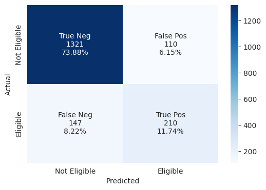

```python
# Checking performance on the testing data

y_test_pred_dt = dt.predict(x_test)

metrics_score(y_test, y_test_pred_dt)
```

```python
dtree = model_performance_classification(dt,x_test,y_test)
dtree
```

|  | Precision | Recall | Accuracy |
| --- | --- | --- | --- |
| 1 | 0.66 | 0.59 | 0.86 |

# **Observations**:

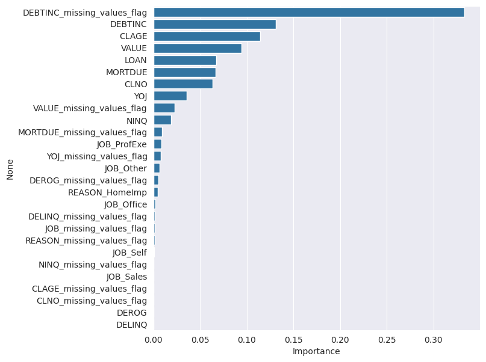

```python
importances = dt.feature_importances_
columns = X.columns
importance_df = pd.DataFrame(importances, index = columns, columns = ['Importance']).sort_values(by = 'Importance', ascending = False)
plt.figure(figsize = (7, 7))
sns.barplot(x=importance_df.Importance, y=importance_df.index)
```

Observations:

According to the Decision Tree, DEBTINC_missing_values_flag is the most important feature, followed by DEBTINC. This signifies that applicants who are at risk of default a loan have high debt and relatively low income

The other important features CLNO, LOAN, CLAGE, VALUE, MORTDUE,CLNO.

### **Decision Tree - Hyperparameter Tuning**

- Hyperparameter tuning is tricky in the sense that **there is no direct way to calculate how a change in the hyperparameter value will reduce the loss of your model**, so we usually resort to experimentation. We'll use Grid search to perform hyperparameter tuning.
- **Grid search is a tuning technique that attempts to compute the optimum values of hyperparameters.**
- **It is an exhaustive search** that is performed on the specific parameter values of a model.
- The parameters of the estimator/model used to apply these methods are **optimized by cross-validated grid-search** over a parameter grid.

**Criterion {“gini”, “entropy”}**

The function to measure the quality of a split. Supported criteria are “gini” for the Gini impurity and “entropy” for the information gain.

**max_depth**

The maximum depth of the tree. If None, then nodes are expanded until all leaves are pure or until all leaves contain less than min_samples_split samples.

**min_samples_leaf**

The minimum number of samples is required to be at a leaf node. A split point at any depth will only be considered if it leaves at least min_samples_leaf training samples in each of the left and right branches. This may have the effect of smoothing the model, especially in regression.

You can learn about more Hyperpapameters on this link and try to tune them.

https://scikit-learn.org/stable/modules/generated/sklearn.tree.DecisionTreeClassifier.html

**Hyperparameter tuning of Decision tree model Using GridSearchCV**

```python
# Choosing the type of classifier.
d_tree_tuned = DecisionTreeClassifier(class_weight = {0: 0.2, 1: 0.8}, random_state = 1)

# Grid of parameters to choose from
parameters = {'max_depth': np.arange(2, 7),
              'criterion': ['gini', 'entropy'],
              'min_samples_leaf': [5, 10, 20, 25]
             }

# Type of scoring used to compare parameter combinations
scorer = metrics.make_scorer(recall_score, pos_label = 1)

# Run the grid search
gridCV = GridSearchCV(d_tree_tuned, parameters, scoring = scorer, cv = 10)


# Fitting the GridSearch on train dataset
gridCV = gridCV.fit(x_train, y_train)


# Setting the clf to the best combination of parameters
d_tree_tunedr = gridCV.best_estimator_


# Fitting the best algorithm to the data.
d_tree_tuned.fit(x_train, y_train)
```

```
DecisionTreeClassifier(class_weight={0: 0.2, 1: 0.8}, random_state=1)
```

Checking performace on training data

```python
# Checking performance on the training data based on the tuned model

y_train_pred_dt = d_tree_tuned.predict(x_train)

metrics_score(y_train, y_train_pred_dt)
```

```
              precision    recall  f1-score   support

           0       1.00      1.00      1.00      3340
           1       1.00      1.00      1.00       832

    accuracy                           1.00      4172
   macro avg       1.00      1.00      1.00      4172
weighted avg       1.00      1.00      1.00      4172
```

```
              precision    recall  f1-score   support

           0       0.90      0.92      0.91      1431
           1       0.66      0.59      0.62       357

    accuracy                           0.86      1788
   macro avg       0.78      0.76      0.77      1788
weighted avg       0.85      0.86      0.85      1788
```

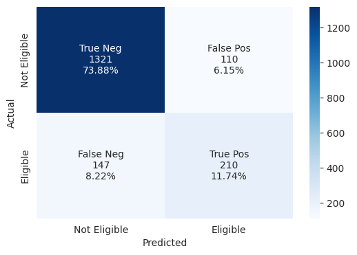

```python
# Checking performance on the testing data based on the tuned model

y_test_pred_dt = d_tree_tuned.predict(x_test)

metrics_score(y_test, y_test_pred_dt)
```

```python
dtree_tuned_test = model_performance_classification(d_tree_tuned,x_test,y_test)
dtree_tuned_test
```

|  | Precision | Recall | Accuracy |
| --- | --- | --- | --- |
| 1 | 0.66 | 0.59 | 0.86 |

**Observation**:

**Hyperparameter tuning of Decision tree model Using RandomizeSearchCV**

```python
from sklearn.model_selection import RandomizedSearchCV

# Choosing the type of classifier.
d_tree_rs = DecisionTreeClassifier(class_weight={0: 0.2, 1: 0.8}, random_state=1)

# Define the parameter distribution to sample from
param_dist = {'max_depth': np.arange(2, 15),
              'criterion': ['gini', 'entropy'],
              'min_samples_leaf': np.arange(5, 50, 5),
              'min_samples_split': np.arange(10, 100, 10)
             }

# Type of scoring used to compare parameter combinations
scorer = metrics.make_scorer(recall_score, pos_label=1)

# Run the randomized search
random_search = RandomizedSearchCV(d_tree_rs, param_distributions=param_dist, n_iter=50, scoring=scorer, cv=10, random_state=1, n_jobs=-1)

# Fitting the RandomizedSearch on train dataset
random_search.fit(x_train, y_train)

# Set the best estimator
d_tree_tuned_rs = random_search.best_estimator_
```

```
              precision    recall  f1-score   support

           0       0.96      0.83      0.89      3340
           1       0.56      0.87      0.68       832

    accuracy                           0.84      4172
   macro avg       0.76      0.85      0.79      4172
weighted avg       0.88      0.84      0.85      4172
```

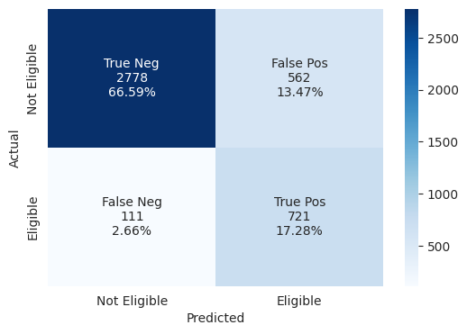

```python
#Checking performance on the training data based on the tuned model

y_train_pred_dt = random_search.predict(x_train)

metrics_score(y_train, y_train_pred_dt)
```

```
              precision    recall  f1-score   support

           0       0.95      0.82      0.88      1431
           1       0.54      0.82      0.65       357

    accuracy                           0.82      1788
   macro avg       0.74      0.82      0.76      1788
weighted avg       0.87      0.82      0.83      1788
```

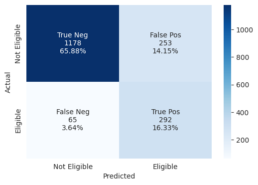

```python
y_test_pred_dt = random_search.predict(x_test)

metrics_score(y_test, y_test_pred_dt)
```

```python
rscv_estimator_test = model_performance_classification(random_search,x_test,y_test)
rscv_estimator_test
```

|  | Precision | Recall | Accuracy |
| --- | --- | --- | --- |
| 1 | 0.54 | 0.82 | 0.82 |

Observations:

- The RandomizedSearchCV tuning seems to have successfully reduced the overfitting observed in the previous Decision Tree models. The performance on the training set is no longer perfect, and the gap between training and testing performance is smaller.
- Crucially, the recall for the minority class (defaulters, Class 1) on the test set has significantly improved (from 0.59 to 0.82).
- The lower precision for Class 1 (0.54) means that when this model predicts a default, there's a higher chance it might be a false positive compared to the previous models

**The precision-recall curve for the Decision Tree model tuned with RandomizedSearchCV**

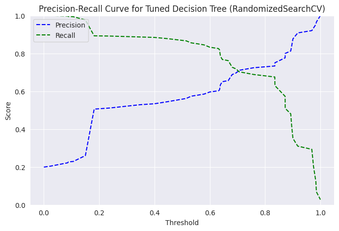

```python
# Get the probability scores for the positive class (Class 1)
y_scores_dt_tuned_rs = random_search.predict_proba(x_train)[:, 1]

# Calculate precision, recall, and thresholds
precisions_dt_tuned_rs, recalls_dt_tuned_rs, thresholds_dt_tuned_rs = precision_recall_curve(y_train, y_scores_dt_tuned_rs)

# Plot the Precision-Recall curve
plt.figure(figsize=(8, 5))
plt.plot(thresholds_dt_tuned_rs, precisions_dt_tuned_rs[:-1], 'b--', label='Precision')
plt.plot(thresholds_dt_tuned_rs, recalls_dt_tuned_rs[:-1], 'g--', label='Recall')
plt.xlabel('Threshold')
plt.ylabel('Score')
plt.title('Precision-Recall Curve for Tuned Decision Tree (RandomizedSearchCV)')
plt.legend(loc='upper left')
plt.ylim([0, 1])
plt.grid(True)
plt.show()
```

```
              precision    recall  f1-score   support

           0       0.92      0.90      0.91      1431
           1       0.64      0.69      0.66       357

    accuracy                           0.86      1788
   macro avg       0.78      0.80      0.79      1788
weighted avg       0.86      0.86      0.86      1788
```

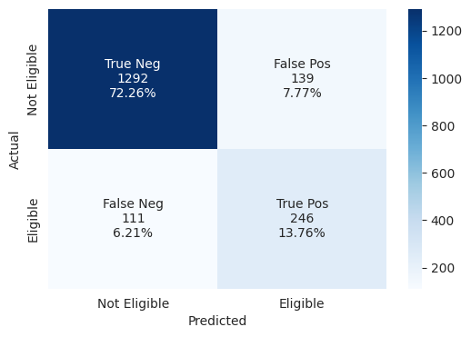

```python
# Choose an optimal threshold based on the Precision-Recall curve
# Replace 'optimal_threshold_dt_tuned_rs' with the value you choose from the plot
optimal_threshold_dt_tuned_rs = 0.65 # Example threshold, adjust based on your interpretation of the plot

# Get the probability scores for the positive class (Class 1) on the test set
y_pred_proba_test_dt = random_search.predict_proba(x_test)[:, 1]

# Predict class labels using the chosen threshold
y_pred_test_thresholded_dt = (y_pred_proba_test_dt > optimal_threshold_dt_tuned_rs).astype(int)

# Evaluate the model's performance at the chosen threshold
metrics_score(y_test, y_pred_test_thresholded_dt)
```

**Observations:**